# Fitting SDMs

2020-05-25

This vignette shows how to fit SDMs with the **WRAP** package and make some basic plots. See the plotting vignette for more details on the plotting functions. The fitting functions in **WRAP** are

- `gam_sdm()`
- `brt_sdm()`
- `mlp_sdm()`

Type `?gam_sdm`, etc, to learn about the arguments for the function.

**WRAP** also includes some plotting functions

- `plot_cog()` Center of gravity
- `plot_abund()` Average abundance

```r
library(WRAP)
```

# Simulate data

There are three simulation functions that can be used. `SimulateWorld_ROMS()` which uses ROMS for the environmental fields, `SimulateWorld_ROMS_TrophicInteractins()` which uses ROMS and trophic interactions, and `SimulateWorld()` which simulates a temperature field.

We will use `SimulateWorld()` for this example. Type `?SimulateWorld` as console to learn more about this function.

Parameters for the function are

- `abund_enviro` can be “lnorm_low” (SB); “lnorm_high” (EW); or “poisson” (JS).
- `PA_shape` can be “logistic” (SB); “logistic_prev”,“linear” (JS)
- `temp_spatial` can be “simple” (SB); or “matern” (EW)
- `temp_diff` is only for the simulated temperature. It specifies min and max temps at year 1 and year 100 (e.g. temp_diff=c(1,3,5,7) means year 1 varies from 1-3C and year 100 from 5-7C).
- `dir` is the directory where ROMS data is stored. The ROMS functions are looking for a directory called `gfdl`. The default assumption is that this is in your working directory in a folder called `Rasters_2d_monthly`.

We will set the parameters to the following for our simulated abundances and presence/absence grid.

```r
abund_enviro <- "lnorm_low"
PA_shape <- "logistic"
temp_spatial <- "matern"
temp_diff <- c(1,4,3,7)
```

Simulate species abundances from the simulated temperature fields.

```r
sim1 <- SimulateWorld(temp_diff = temp_diff,
                      temp_spatial = temp_spatial,
                      PA_shape = PA_shape,
                      abund_enviro = abund_enviro,
                      n.year=40, start.year=2015)
```

Printing the output will show you basic information about the simulation. This information is in `sim1$meta`.

```r
sim1
## Simulated species abundance and suitability from WRAP version 1.5 and function SimulateWorld
##    covariates: temp
##    grid.dimensions: 20, 20, 400 (nrow, ncol, cells)
##    grid.resolution 1, 1 (x, y)
##    grid.extent 1, 20, 1, 20 (xmin, xmax, ymin, ymax)
##    grid.units: not applicable
##    time.extent: 2016 to 2055 year
```

## Save data

Since simulations take a long time to run, you may want to create a directory in your working directory for the simulations and save them there. Then you can reload the simulations instead of re-running.

Create a directory for the simulations:

```r
if(!dir.exists(file.path(here::here(), 'Sim1')))
  dir.create(file.path(here::here(), 'Sim1'))
```

Save the simulation.

```r
saveRDS(sim1, file=file.path(here::here(), "Sim1", "Sim1.rds"))
```

## Plot the simulated data

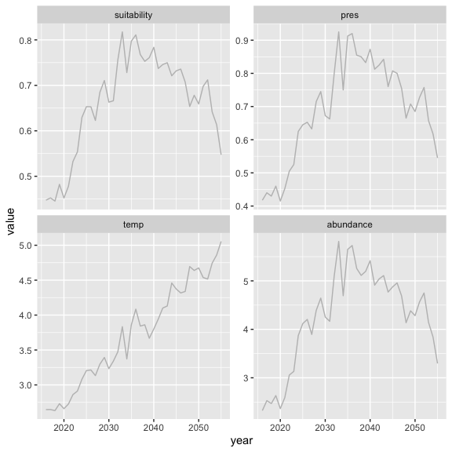

```r
plot(sim1, start.forecast.year=2020)
```

# Fit SDMs to the simulated grid

We will fit GAM, BRT and MLP SDM models to the simulated grids. The fit function will fit the correct model (lognormal or poisson) based on the value of `abund_enviro`. If you want to restrict the smoothing, you can pass in `k` to the GAM function. The default fitting period is years prior to 2021 (`start.forecast.year=2021`). The fitting function will return both the presence and abundance models.

```r
gam.fit <- gam_sdm(sim1, covariates="temp")
gam.p <- gam.fit$presence
gam.a <- gam.fit$abundance

brt.fit <- brt_sdm(sim1, covariates="temp")
brt.p <- brt.fit$presence
brt.a <- brt.fit$abundance

mlp.fit <- mlp_sdm(sim1, covariates="temp")
mlp.p <- mlp.fit$presence
mlp.a <- mlp.fit$abundance
```

# Create Predictions for a new covariate range

Now plot the comparison of the models for temperaturs 0 to 7C.

First we need to set up the temperatures used for prediction.

```r
new_dat <- data.frame(temp=seq(0,7,length=100))
```

The `predict.OM()` function will compute the predicted presence, abundance and expected abundance (pred presence x pred abundance). You can (optionally) pass in a fitted model. If you do not, the predict function will fit a SDM based on the `model` argument (e.g. `predict(sim1, model="gam")`). We will pass in the fitted SDMs to speed up the predictions. This predict function for a OM object returns a data frame with pred.p, pred.a, pred and CIs added (pred is expected abundance = pred$pred.p*exp(pred$pred.a)). A column pred.type indicates the type of prediction: hindcast, forecast, or newdata.

```r
pred.gam <- predict(sim1, sdm=gam.fit, newdata=new_dat)
pred.brt <- predict(sim1, sdm=brt.fit, newdata=new_dat)
pred.mlp <- predict(sim1, sdm=mlp.fit, newdata=new_dat)
```

## Plot Predictions

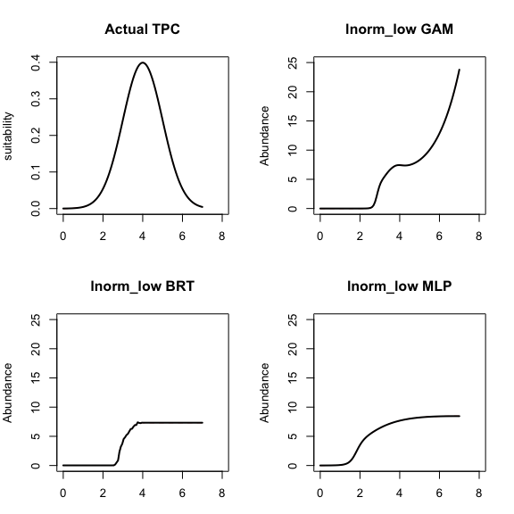

```r
par(mfrow=c(2,2), mar=c(3,4,4,2))
ylim2 <- 1.05*max(pred.gam$pred, pred.brt$pred, pred.mlp$pred)

#actual TPC
xx <- seq(0, 7, length=100)
#yy must match response function in SimulateWorld function (sim1$meta$response.curve$temp)
yy <- dnorm(xx, mean=4, sd=1)
plot(xx, yy, type="l", lty=2, main="Actual TPC", col="red", xlim=c(0,8), ylab="suitability", xlab="Temp")
xlim <- round(100*(max(new_dat$temp)/7))
lines(xx[1:xlim], yy[1:xlim], lwd=2)

#gam
plot(new_dat$temp, pred.gam$pred, type="l",
     main="lnorm_low GAM", xlim=c(0,8), col="red", lty=2, ylim=c(0,ylim2), ylab="Abundance", xlab="Temp")
lines(new_dat$temp, pred.gam$pred, lwd=2)

#brt
plot(new_dat$temp, pred.brt$pred, type="l",
     main="lnorm_low BRT", xlim=c(0,8), col="red", lty=2, ylim=c(0,ylim2), ylab="Abundance", xlab="Temp")
lines(new_dat$temp, pred.brt$pred, lwd=2)

#MLP
plot(new_dat$temp, pred.mlp$pred, type="l",
     main="lnorm_low MLP", xlim=c(0,8), col="red", lty=2, ylim=c(0,ylim2), ylab="Abundance", xlab="Temp")
lines(new_dat$temp, pred.mlp$pred, lwd=2)
```

```r
par(mfrow=c(1,1))
```

# Make predictions for the years and values in the simulation

If `newdata` is left off, `predict(sim)` where `sim` is the output from one of the simulation functions (operating model) will return a data frame with a hindcast for years before start.forecast.year and a forecast after that. See `?predict.OM` for other arguments that this function takes.

You can pass in a previously fitted SDM to speed up the function as we did before. But you can leave these off and `predict` will fit the SDM based on the value in `sim$meta$abund_enviro`. Specify the SDM model with argument `model`.

```r
pred.gam2 <- predict(sim1, model="gam")
pred.brt2 <- predict(sim1, model="brt")
pred.mlp2 <- predict(sim1, model="mlp")
```

This will re-estimate the fitted models. This won’t make a difference for gam and brt, but will for the mlp model with the default settings since that is a stochastic fit. We can pass in our fits so that we use a known model.

```r
pred.gam2 <- predict(sim1, sdm=gam.fit)
pred.brt2 <- predict(sim1, sdm=brt.fit)
pred.mlp2 <- predict(sim1, sdm=mlp.fit)
```

Assemble the predictions into one data frame.

```r
nr <- nrow(pred.gam2)
pred.all <- rbind(pred.gam2, pred.brt2, pred.mlp2)
pred.all$model <- c(rep("gam", nr), rep("brt", nr), rep("mlp", nr))
```

## Plot a prediction

Ploting the object will show the yearly averages.

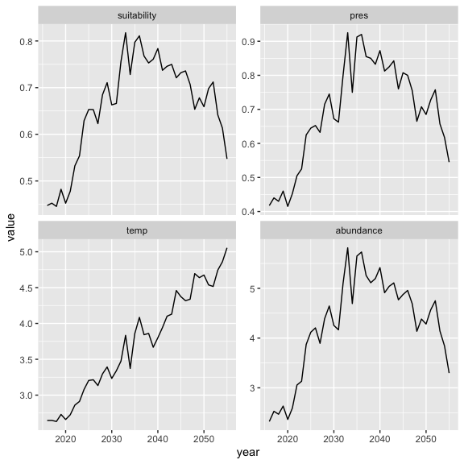

```r
plot(sim1)
```

## Compare abundance predictons

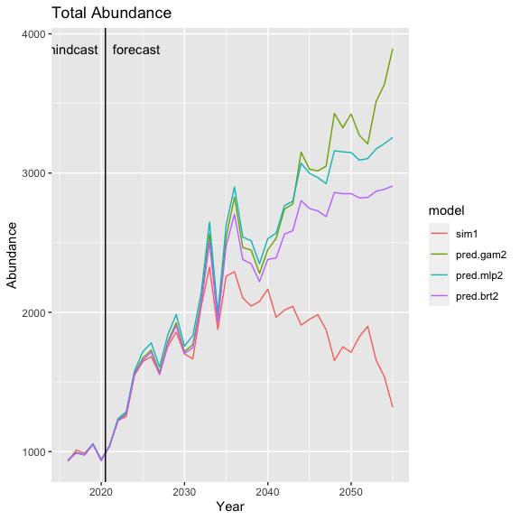

```r
plot_abund(sim1, pred.gam2, pred.mlp2, pred.brt2)
```

## Calculate and plot centre of gravity

The function `plot_cog()` will plot the center of gravity of the true data (from the simulation) and the fitted models. The required argument is the simulated data (`sim1`), after that you can add as many fitted or prediction objects as you want to compare.

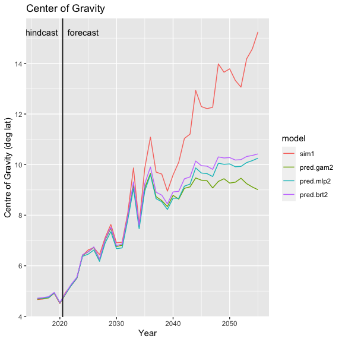

```r
plot_cog(sim1, pred.gam2, pred.mlp2, pred.brt2)
```

## Plot average presence

The function `plot_pres()` will plot the average presence.

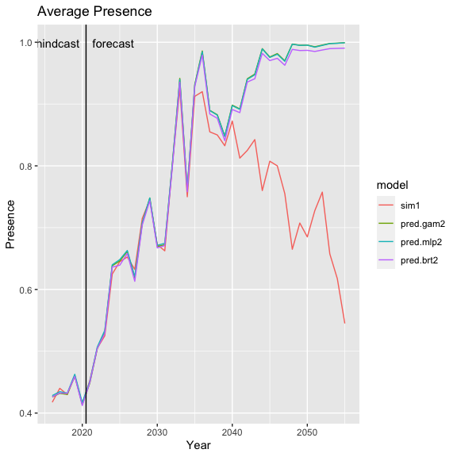

```r
plot_pres(sim1, pred.gam2, pred.mlp2, pred.brt2)
```

## Plot abundance on a grid

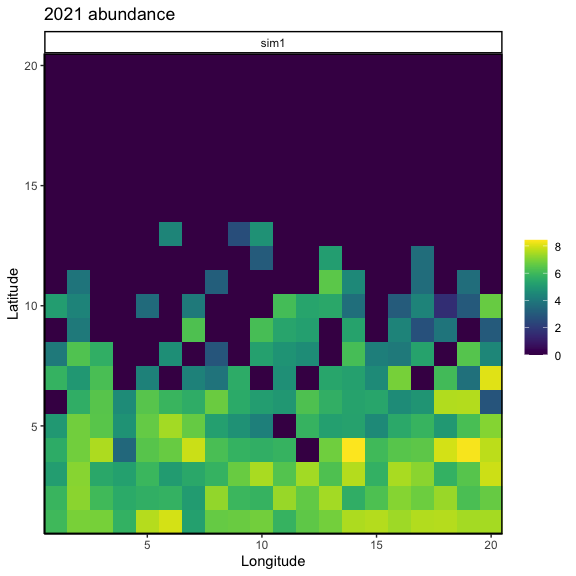

```r
plot_grid(sim1, year=2021, pred.gam, pred.mlp, pred.brt)
```

```r
# You can also pass in SDMs but the predictions will be computed (slow)
# plot_grid(sim1, year=2021, gam.fit, mlp.fit, brt.fit)
```